# PE Study

Carlos Brown

01/02/2020

## Introduction

There are two major types of Pulmonary Embollism that present in patients, Saddle and Non-Saddle. For low risk patients, defined here as submassive, is there a difference in adverse event rates between Saddle and Non-Saddle patients? We would also like to investigate the predictive power of traditional risk stratifiers like sPESI / PESI, and compare to BOVA Score.

## Definitions

- Within this study, the term adverse event rate and adverse event count are synonymous.
- PE = Pulmonary Embollism
- Submassive refers to patients with PE Severity of 1 or 2. A score of 3 indicates Massive.
- In the 2x2 tables, 1 indicates an adverse event, 0 indicates no adverse event

## Initial Processing

Change types and rename

```r
df_model <- df_model %>% rename(Severity = PE.Severity.1.low.risk..2.intermediate..3.massive..4.indeterminate)
df_model$type <- as.factor(df_model$type)
df_model$Gender <- as.factor(df_model$Gender)
df_model$Race <-as.factor(df_model$Race)
df_model$BOVA.Score <- as.factor(df_model$BOVA.Score)
```

Filter for low risk patients by PE Severity

```r
df_all <- df_model %>% filter(Severity < 3)
df_all$Severity <- as.factor(df_all$Severity)
```

Bin by age

```r
breaks = 5
df_all$age_bin <- cut(df_all$Age, breaks=breaks)
```

## What constitutes an Adverse Event?

1. Death, either in hospital or within 30 days of release
2. Arrhythmia that required treatment
3. Inotropes
4. Vasopressors
5. Use of Non-Rebreather mask
6. Shock
7. ACLS
8. Intubation
9. tPA
10. Transfusion
11. EKOS

## Visualize Distributions

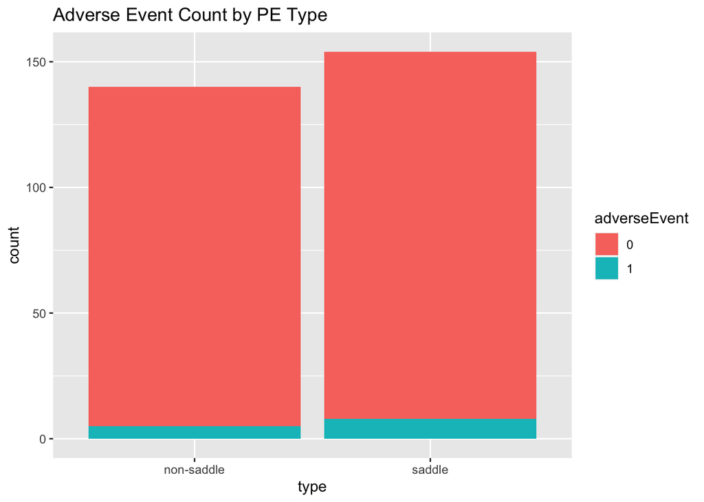

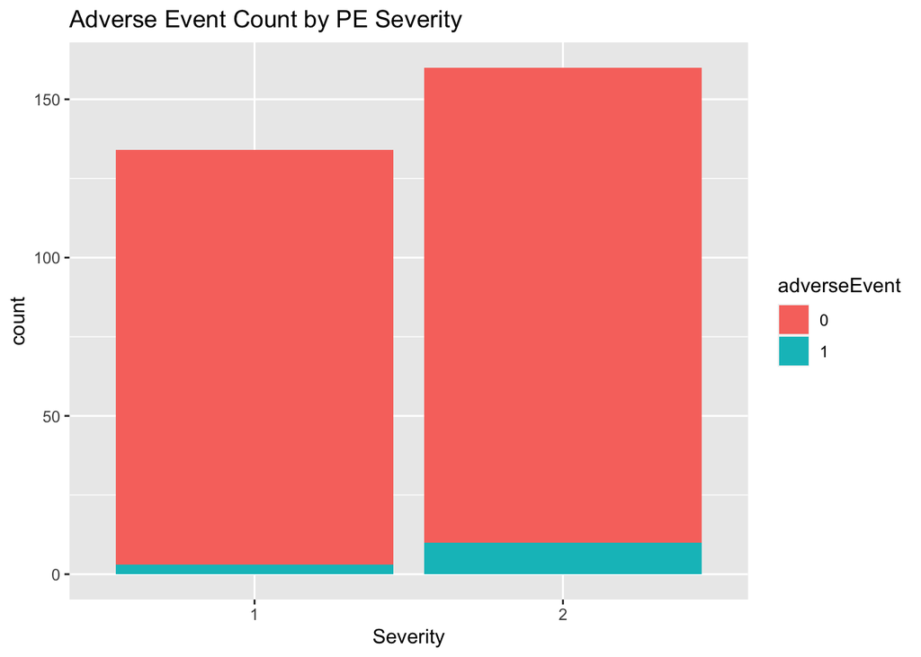

### Severity is a potential confounder, noticing the slight correlation with adverse event rates

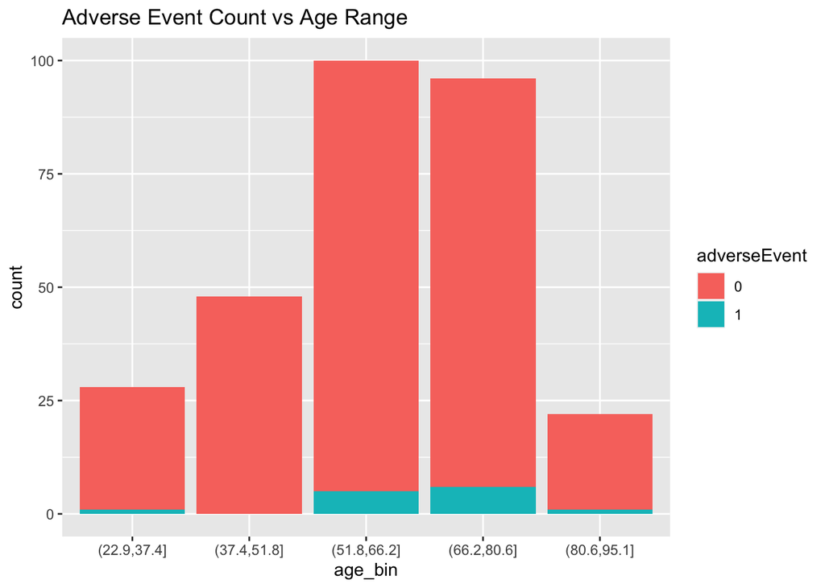

## 2x2 Tables

### 2x2 Table for entire cohort

```r
# table_group <- table(df_all$adverseEvent, df_all$type, df_all$age_bin)
test_mat <- as.matrix(table(df_all$type, df_all$adverseEvent))
test_mat
```

```
##
##                0   1
##   non-saddle 135   5
##   saddle     146   8
```

### 2x2 Table for cohort, by PE Severity

```r
table(df_all$type, df_all$adverseEvent, df_all$Severity)
```

```
## , ,  = 1
##
##
##                0   1
##   non-saddle  94   1
##   saddle      37   2
##
## , ,  = 2
##
##
##                0   1
##   non-saddle  41   4
##   saddle     109   6
```

## Check for confounding

```r
m_crude <- glm(formula = 'adverseEvent ~ type', data = df_all, family = binomial)
summary(m_crude)
```

```
##
## Call:
## glm(formula = "adverseEvent ~ type", family = binomial, data = df_all)
##
## Deviance Residuals:
##     Min       1Q   Median       3Q      Max
## -0.3266  -0.3266  -0.2697  -0.2697   2.5816
##
## Coefficients:
##             Estimate Std. Error z value Pr(>|z|)
## (Intercept)  -3.2958     0.4554  -7.237 4.59e-13 ***
## typesaddle    0.3917     0.5825   0.672    0.501
## ---
## Signif. codes:  0 '***' 0.001 '**' 0.01 '*' 0.05 '.' 0.1 ' ' 1
##
## (Dispersion parameter for binomial family taken to be 1)
##
##     Null deviance: 106.50  on 293  degrees of freedom
## Residual deviance: 106.04  on 292  degrees of freedom
## AIC: 110.04
##
## Number of Fisher Scoring iterations: 6
```

```r
m_adj <- glm(formula = 'adverseEvent ~ type + Age + Severity + Race + Gender', data = df_all, family = binomial)
summary(m_adj)
```

```
##
## Call:
## glm(formula = "adverseEvent ~ type + Age + Severity + Race + Gender",
##     family = binomial, data = df_all)
##
## Deviance Residuals:
##     Min       1Q   Median       3Q      Max
## -0.5006  -0.3600  -0.2568  -0.1984   2.7476
##
## Coefficients:
##               Estimate Std. Error z value Pr(>|z|)
## (Intercept)  -19.05928 3956.18053  -0.005    0.996
## typesaddle     0.08057    0.62988   0.128    0.898
## Age            0.02755    0.02139   1.288    0.198
## Severity2      0.94037    0.72126   1.304    0.192
## RaceB         13.57175 3956.18041   0.003    0.997
## RaceH         -1.23444 4805.32103   0.000    1.000
## RaceNH        -1.14524 4322.76564   0.000    1.000
## Racerefused   -0.65935 5594.88396   0.000    1.000
## RaceW         13.50987 3956.18040   0.003    0.997
## GenderM        0.11571    0.60291   0.192    0.848
## GenderM      -14.69737 3956.18039  -0.004    0.997
##
## (Dispersion parameter for binomial family taken to be 1)
##
##     Null deviance: 106.50  on 293  degrees of freedom
## Residual deviance: 100.55  on 283  degrees of freedom
## AIC: 122.55
##
## Number of Fisher Scoring iterations: 16
```

### Calculate percent change in typesaddle coefficient between models. If absolute value is greater than 10%, confounding needs to be adjusted for.

```r
beta_crude <- coefficients(m_crude)[['typesaddle']]
beta_adj <- coefficients(m_adj)[['typesaddle']]
(beta_adj - beta_crude) / beta_crude
```

```
## [1] -0.794297
```

Confounding is present, however the GLM models suggest that there is no relationship between adverse event rates and PE type (saddle vs non-saddle)

Compare to VGAM package outputs for sanity check

```r
m_vgam <- vglm(formula = 'adverseEvent ~ type + Age + Severity + Race + Gender', binomialff(link = "logitlink"), data = df_all)
coefficients(m_vgam)[['typesaddle']]
```

```
## [1] 0.08056805
```

The predictor “type” is confounded by adding in further predictors such as Age, Severity, and Race. Severity alone is the most powerful confounder and should be controlled for. We will use the Cochran-Mantel-Haenszel to account for the observed confounding effect of Severity.

### Hypothesis test is set based on what constitutes surprise for the doctor.

**H0**: There is no difference in the adverse event odds ratio of saddle vs non-saddle in severity controlled groups

**H1**: There is a difference in the adverse event odds ratio of saddle vs non-saddle in severity controlled groups

Odds ratio in this case is defined as…

(saddle adverse event count / saddle no adverse event count) / (non-saddle adverse event count / non-saddle no adverse event count)

### Test 1: Fisher’s exact test for entire cohort

```r
m_fisher <- exact2x2(test_mat, conf.level = 0.99)
m_fisher
```

```
##
##  Two-sided Fisher's Exact Test (usual method using minimum likelihood)
##
## data:  test_mat
## p-value = 0.5782
## alternative hypothesis: true odds ratio is not equal to 1
## 99 percent confidence interval:
##  0.3357 7.6156
## sample estimates:
## odds ratio
##   1.477511
```

Based on test results, we do not reject the null hypothesis, however we will still control for confounding factor of PE Severity. Use the Cochran-Mantel-Haenszel test.

### Test 2: Cochran-Mantel-Haenszel test to control for PE Severity

```r
m_cmh <- mantelhaen.test(table(df_all$type, df_all$adverseEvent, df_all$Severity), exact = TRUE)
m_cmh
```

```
##
##  Exact conditional test of independence in 2 x 2 x k tables
##
## data:  table(df_all$type, df_all$adverseEvent, df_all$Severity)
## S = 135, p-value = 1
## alternative hypothesis: true common odds ratio is not equal to 1
## 95 percent confidence interval:
##  0.2456193 4.3600803
## sample estimates:
## common odds ratio
##          0.976237
```

We notice that after controlling for PE Severity in submassive patients, there is no evidence to suggest a statistically significant or practically significant difference in the adverse event counts between saddle and non-saddle pulmonary embollism.

Control for multiple comparisons using Benjamini & Yekutieli correction

```r
pvalues <- c(m_fisher$p.value, m_cmh$p.value)
p.adjust(pvalues, method = "BY")
```

```
## [1] 1 1
```

Given the multiple comparisons correction, and our alpha value of 1%, both tests have given p-values where we cannot reject the null hypothesis in favor of the alternate hypothesis. The common odds ratio confidence interval for adverse events in saddle over non-saddle is…

0.2456193, 4.3600803

**Submassive Patients with Saddle PE are no more likely to experience an adverse event as those with Non-Saddle PE**

## How predictive are PESI, sPESI, and BOVA?

```r
m_pred_spesi <- glm(formula = 'adverseEvent ~ sPESI', data = df_model, family = binomial)
PseudoR2(m_pred_spesi, which = 'McKelveyZavoina')
```

```
## McKelveyZavoina
##       0.3473808
```

```r
summary(m_pred_spesi)
```

```
##
## Call:
## glm(formula = "adverseEvent ~ sPESI", family = binomial, data = df_model)
##
## Deviance Residuals:
##     Min       1Q   Median       3Q      Max
## -0.5105  -0.5105  -0.5105  -0.1310   3.0861
##
## Coefficients:
##             Estimate Std. Error z value Pr(>|z|)
## (Intercept)   -4.754      1.004  -4.733 2.21e-06 ***
## sPESI          2.782      1.025   2.714  0.00666 **
## ---
## Signif. codes:  0 '***' 0.001 '**' 0.01 '*' 0.05 '.' 0.1 ' ' 1
##
## (Dispersion parameter for binomial family taken to be 1)
##
##     Null deviance: 193.1  on 337  degrees of freedom
## Residual deviance: 175.6  on 336  degrees of freedom
## AIC: 179.6
##
## Number of Fisher Scoring iterations: 7
```

```r
m_pred_pesi <- glm(formula = 'adverseEvent ~ PESI.Class', data = df_model, family = binomial)
PseudoR2(m_pred_pesi, which = 'McKelveyZavoina')
```

```
## McKelveyZavoina
##       0.3012967
```

```r
summary(m_pred_pesi)
```

```
##
## Call:
## glm(formula = "adverseEvent ~ PESI.Class", family = binomial,
##     data = df_model)
##
## Deviance Residuals:
##     Min       1Q   Median       3Q      Max
## -0.7894  -0.3462  -0.2239  -0.1441   3.0242
##
## Coefficients:
##             Estimate Std. Error z value Pr(>|z|)
## (Intercept)  -5.4515     0.7631  -7.144 9.04e-13 ***
## PESI.Class    0.8890     0.1842   4.826 1.39e-06 ***
## ---
## Signif. codes:  0 '***' 0.001 '**' 0.01 '*' 0.05 '.' 0.1 ' ' 1
##
## (Dispersion parameter for binomial family taken to be 1)
##
##     Null deviance: 193.10  on 337  degrees of freedom
## Residual deviance: 162.67  on 336  degrees of freedom
## AIC: 166.67
##
## Number of Fisher Scoring iterations: 6
```

```r
m_pred_bova <- glm(formula = 'adverseEvent ~ BOVA.Score', data = df_model, family = binomial)
PseudoR2(m_pred_bova, which = 'McKelveyZavoina')
```

```
## McKelveyZavoina
##       0.9658163
```

```r
summary(m_pred_bova)
```

```
##
## Call:
## glm(formula = "adverseEvent ~ BOVA.Score", family = binomial,
##     data = df_model)
##
## Deviance Residuals:
##      Min        1Q    Median        3Q       Max
## -0.60386  -0.34305  -0.31495  -0.00005   2.62068
##
## Coefficients:
##                                                   Estimate Std. Error z value
## (Intercept)                                        -2.8034     0.7282  -3.850
## BOVA.Score0                                       -17.7627  1722.1259  -0.010
## BOVA.Score1                                         1.0116     0.9587   1.055
## BOVA.Score2                                        -0.1756     0.9384  -0.187
## BOVA.Score3                                         0.2384     1.0338   0.231
## BOVA.Score4                                        -0.5978     1.2505  -0.478
## BOVA.Score5                                         1.0986     0.8528   1.288
## BOVA.Score7                                         1.1939     1.3154   0.908
## BOVA.Scoredoes not qualify for scoring, SBP <90    23.3694 12537.2648   0.002
## BOVA.Scoredoes not quality for scoring, BP <90     23.3694  6701.4500   0.003
## BOVA.Scoredoes not quality for scoring, SBP <90    23.3694 17730.3699   0.001
##                                                 Pr(>|z|)
## (Intercept)                                     0.000118 ***
## BOVA.Score0                                     0.991770
## BOVA.Score1                                     0.291366
## BOVA.Score2                                     0.851590
## BOVA.Score3                                     0.817615
## BOVA.Score4                                     0.632582
## BOVA.Score5                                     0.197663
## BOVA.Score7                                     0.364067
## BOVA.Scoredoes not qualify for scoring, SBP <90 0.998513
## BOVA.Scoredoes not quality for scoring, BP <90  0.997218
## BOVA.Scoredoes not quality for scoring, SBP <90 0.998948
## ---
## Signif. codes:  0 '***' 0.001 '**' 0.01 '*' 0.05 '.' 0.1 ' ' 1
##
## (Dispersion parameter for binomial family taken to be 1)
##
##     Null deviance: 193.10  on 337  degrees of freedom
## Residual deviance: 118.72  on 327  degrees of freedom
## AIC: 140.72
##
## Number of Fisher Scoring iterations: 19
```

Both sPESI and PESI Class are significant predictors of adverse event rates and have similar predictive power. Surprisingly, BOVA score has a high Pseudo R2 value, as well as having a lower AIC value compared to sPESI and PESI, suggesting that it is a better diagnostic tool for predicting adverse events than sPESI or PESI are.